# HW Week 4 Data 624

## Problem 5.4

**Repeat the previous exercise using the Australian Exports series from** global_economy **and the Bricks series from** aus_production. **Use whichever of Naive() or SNAIVE() is more appropriate in each case.**

```r
head(global_economy, 3)
```

```
## # A tsibble: 3 x 9 [1Y]
## # Key:       Country [1]
##   Country     Code   Year        GDP Growth   CPI Imports Exports Population
##   <fct>       <fct> <dbl>      <dbl>  <dbl> <dbl>   <dbl>   <dbl>      <dbl>
## 1 Afghanistan AFG    1960 537777811.     NA    NA    7.02    4.13    8996351
## 2 Afghanistan AFG    1961 548888896.     NA    NA    8.10    4.45    9166764
## 3 Afghanistan AFG    1962 546666678.     NA    NA    9.35    4.88    9345868
```

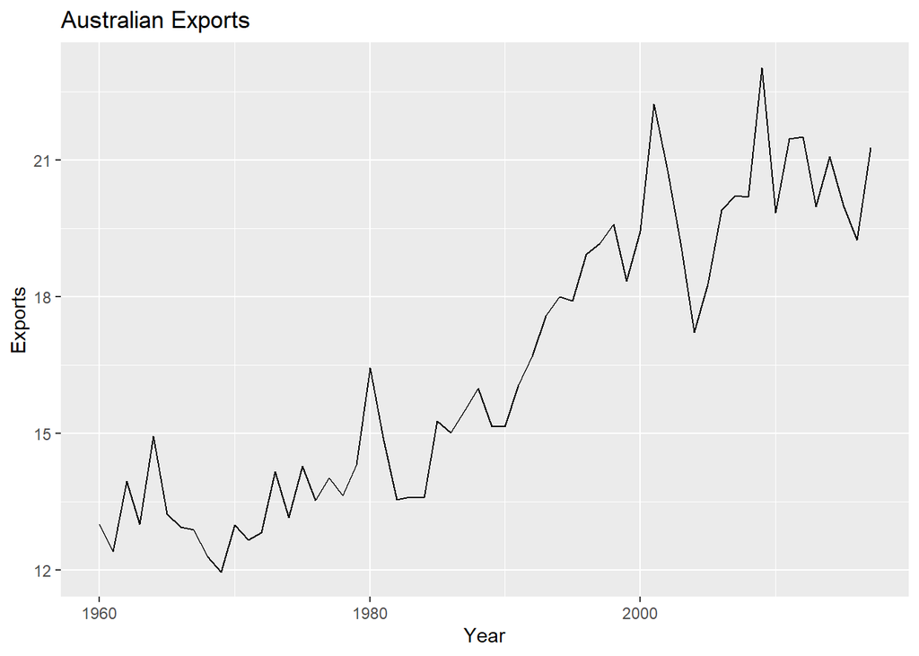

```r
aus_export <- global_economy |>
  filter( Code == 'AUS')|>
  select(Exports)
autoplot(aus_export, Exports)+
  labs(title =  'Australian Exports',
        x= 'Year', y = 'Exports')
```

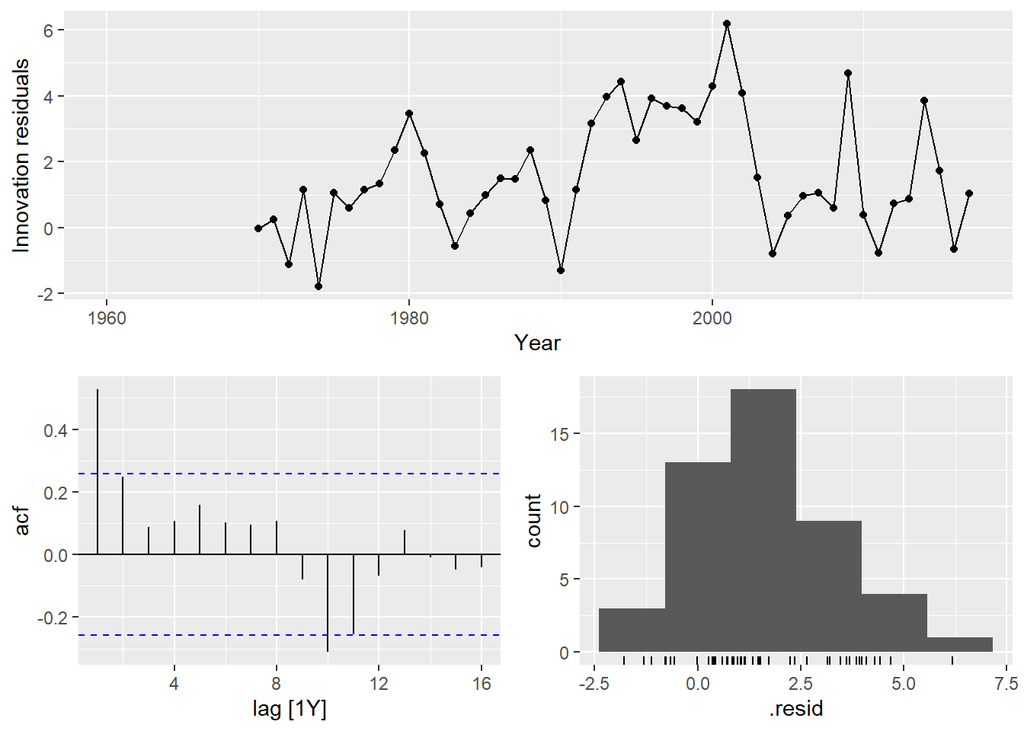

```r
# Define and estimate a model
fit <- aus_export|> model(SNAIVE(Exports~ lag(10)))
# Look at the residuals
fit |> gg_tsresiduals()
```

```r
# Look a some forecasts
```

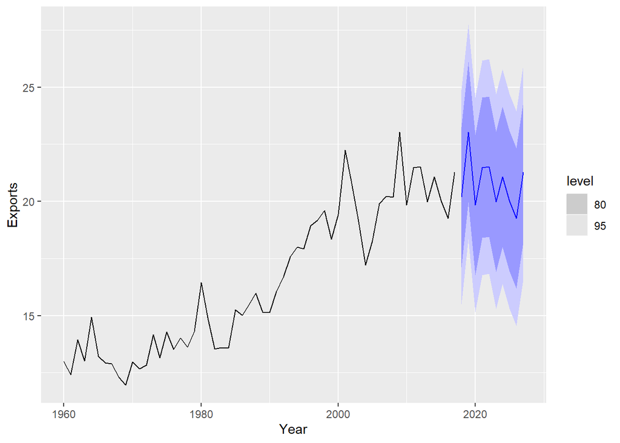

```r
fit |> forecast(h=10) |> autoplot(aus_export)
```

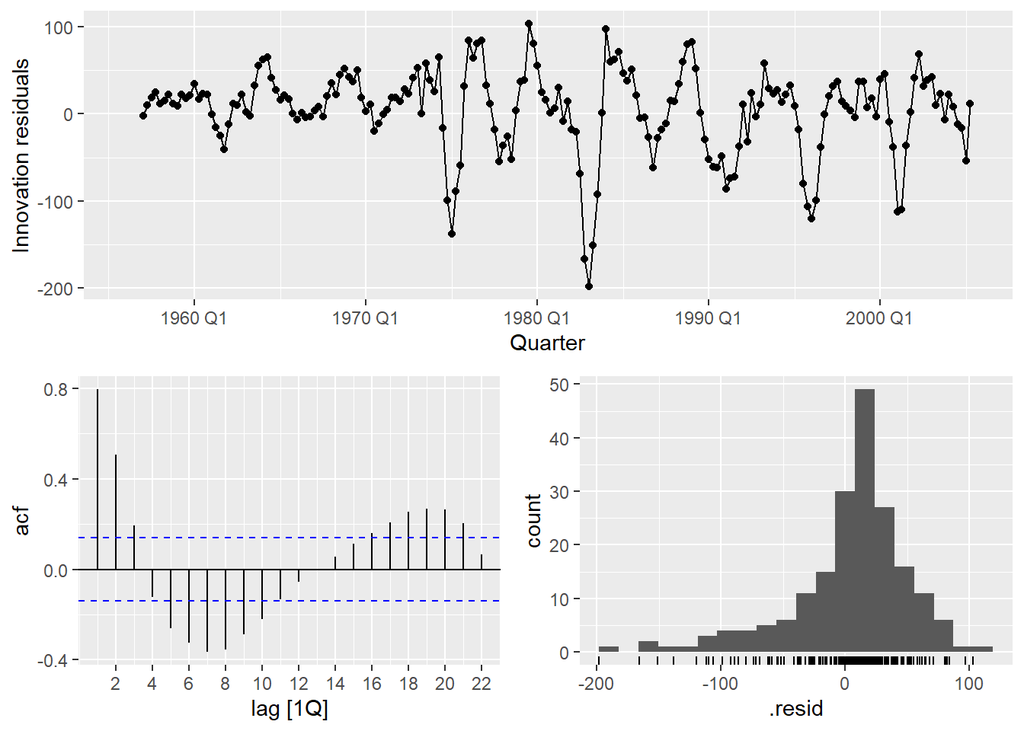

```r
fit <- aus_production |>
  filter(!is.na(Bricks))|>
  model(SNAIVE(Bricks ~ lag("year")))
# Look at the residuals
fit %>% gg_tsresiduals()
```

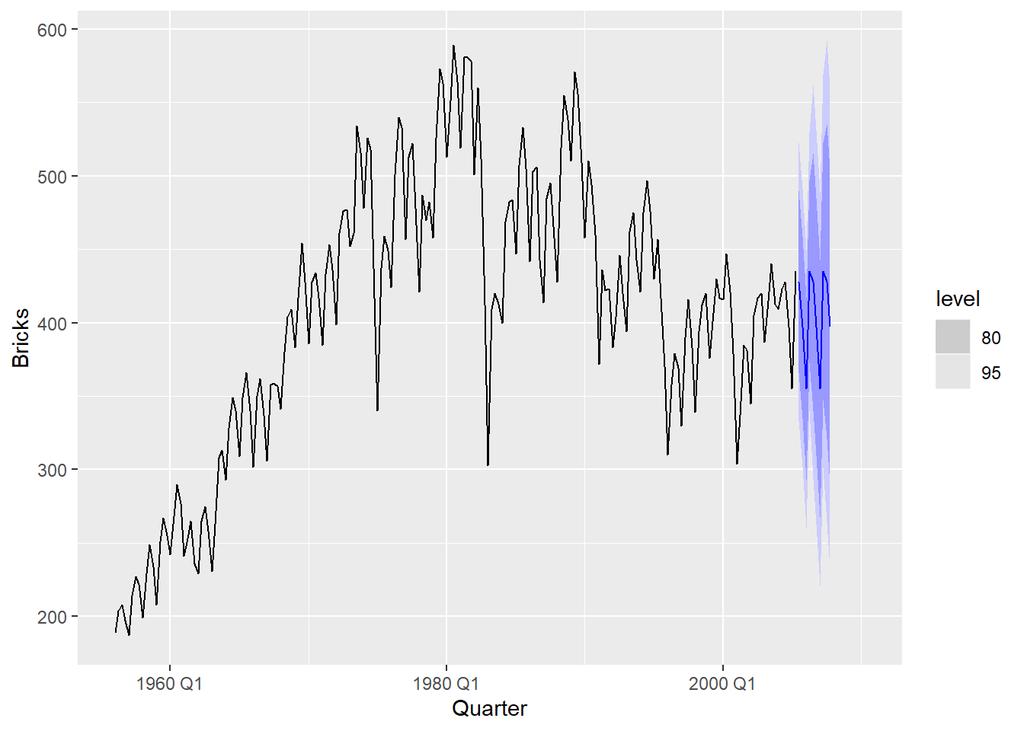

```r
# Look a some forecasts
fit |> forecast(h=10) |> autoplot(aus_production)
```

## Problem 5.7

**For your retail time series (from exercise 7 in Section 2.10):**

1. Create a training dataset consisting of observations before 2011 using

```r
set.seed(12345678)
myseries <- aus_retail |>
  filter(`Series ID` == sample(aus_retail$`Series ID`,1))

myseries_train <- myseries |>
  filter(year(Month) < 2011)
```

3. Fit a seasonal naive model using SNAIVE() applied to your training data (myseries_train).

```r
fit <- myseries_train |>
  model(snaive = SNAIVE(Turnover))
```

4. Check the residuals.

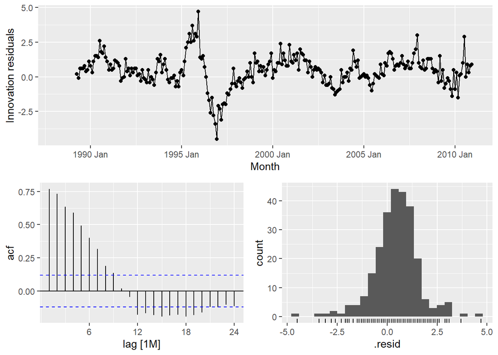

```r
fit |> gg_tsresiduals()
```

5. Produce forecasts for the test data

```r
fc <- fit |>
  forecast(new_data = anti_join(myseries, myseries_train))
```

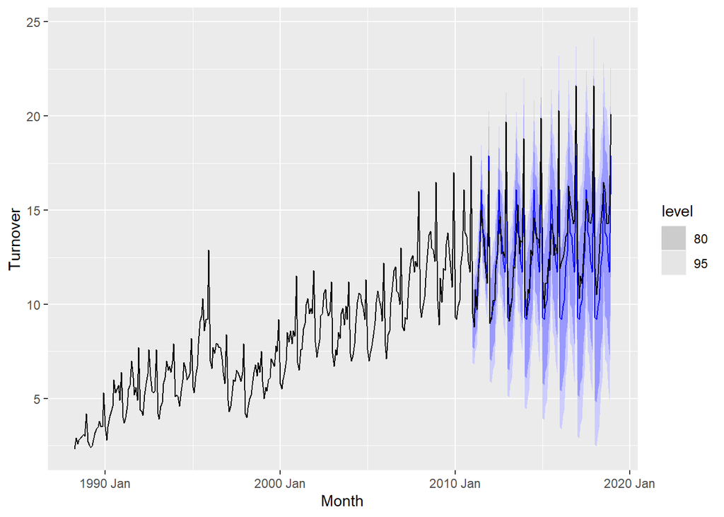

```r
fc |> autoplot(myseries)
```

6. Compute the accuracy of your forecasts against the actual values.

```r
fit |> accuracy()
```

```
## # A tibble: 1 × 12
##   State    Industry .model .type    ME  RMSE   MAE   MPE  MAPE  MASE RMSSE  ACF1
##   <chr>    <chr>    <chr>  <chr> <dbl> <dbl> <dbl> <dbl> <dbl> <dbl> <dbl> <dbl>
## 1 Norther… Clothin… snaive Trai… 0.439  1.21 0.915  5.23  12.4     1     1 0.768
```

```r
fc |> accuracy(myseries)
```

```
## # A tibble: 1 × 12
##   .model State    Industry .type    ME  RMSE   MAE   MPE  MAPE  MASE RMSSE  ACF1
##   <chr>  <chr>    <chr>    <chr> <dbl> <dbl> <dbl> <dbl> <dbl> <dbl> <dbl> <dbl>
## 1 snaive Norther… Clothin… Test  0.836  1.55  1.24  5.94  9.06  1.36  1.28 0.601
```

7. How sensitive are the accuracy measures to the amount of training data used?

The accuracy measures are sensitive to the proportion of data as training data. If the proportions of training data is more than 90% then the model might be over-fit and can give very accurate result but on unseen lasrge dataset, the model might behave badly. If the proportion of training data is toos less like less than 50% then the model is under fit and may give very inaccurate result. So there is need of balance of training and test dataset. It’s considered a good practice to use 80% of the dataset as the training dataset and rest 20% as the validation or test dataset.